# Dynamic Conditional Betas

Vitalii Rudko

November, 2020

# 1 Preparing Data

This section is completely technical, so it may be omitted.

```r
#Loading packages.
library(fintools)
library(xts)
library(vars)
library(ggplot2)
library(forecast)
library(MTS)
library(roll)
library(fDMA)
library(tseries)
library(gridExtra)
library(rugarch)
library(rmgarch)
```

```r
#Importing data.
tickers <-c("^GSPC", "TSLA")
data <- yahoo_quotes(tickers,
                     origin = '2019-11-13')

names(data) <- c("Date","SP500", "TSLA")
```

```r
#Calculating log-returns.
data <- cbind(data, logret(data, omit_na = F)[,2:3])
names(data) <- c("Date","SP500", "TSLA", "SP500_r", "TSLA_r")
```

```r
#Formatting Date column.
data$Date <- as.Date(data$Date)
```

```r
#Creating time series.
sp500_ts <- ts(na.omit(data$SP500_r), start = c(2019, 220), frequency = 253)
tsla_ts <- ts(na.omit(data$TSLA_r), start = c(2019, 220), frequency = 253)
```

```r
#Creating time series in xts fromat.
sp500_xts <- na.omit(xts(data$SP500_r, order.by = data$Date))
tsla_xts <- na.omit(xts(data$TSLA_r, order.by = data$Date))
whole <- na.omit(as.xts(cbind(data$SP500_r, data$TSLA_r), order.by = data$Date))
names(whole) <- c("SP500", "TSLA")
```

# 2 Preliminary Analysis

The data for the period of 11/13/2019 – 11/15/2020 is ready, so we can start working on it. First, let’s plot quotes and log-returns. It is obvious that Tesla is more risky than the index. Tesla experienced at least two shocks, while the index only one. Also, the interquartile range of Tesla returns is wider.

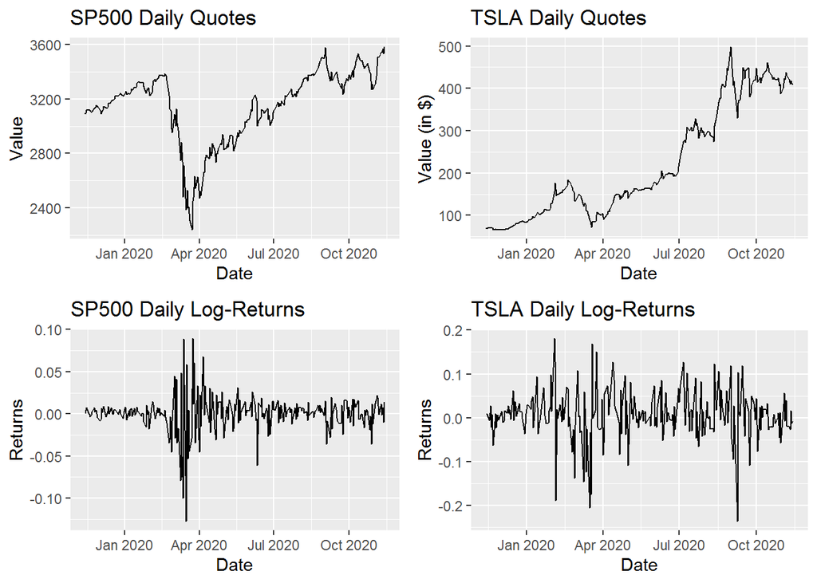

```
##       Min.    1st Qu.     Median       Mean    3rd Qu.       Max.
## -0.1276522 -0.0057976  0.0023510  0.0005823  0.0087551  0.0896832
```

```
##      Min.   1st Qu.    Median      Mean   3rd Qu.      Max.
## -0.236518 -0.018755  0.007180  0.007016  0.030555  0.181445
```

```r
#Plotting quotes and returns.
plot1 <- ggplot(data)+
          geom_line(aes(x = Date, y = SP500))+
          labs(title = "SP500 Daily Quotes",
               y = "Value")
plot2 <- ggplot(data)+
          geom_line(aes(x = Date, y = TSLA))+
          labs(title = "TSLA Daily Quotes",
               y = "Value (in $)")
plot3 <- ggplot(na.omit(data))+
          geom_line(aes(x = Date, y = SP500_r))+
          labs(title = "SP500 Daily Log-Returns",
               y = "Returns")
plot4 <- ggplot(na.omit(data))+
          geom_line(aes(x = Date, y = TSLA_r))+
          labs(title = "TSLA Daily Log-Returns",
               y = "Returns")

grid.arrange(plot1,
             plot2,
             plot3,
             plot4,
             ncol=2)
```

As we see in the plots below, data is not normally distributed, which is not something special. However, Tesla has thicker right tail, which means there are more excess positive returns, than negative, and S&P500 has thicker left tail, which means more excess negative returns, than positive.

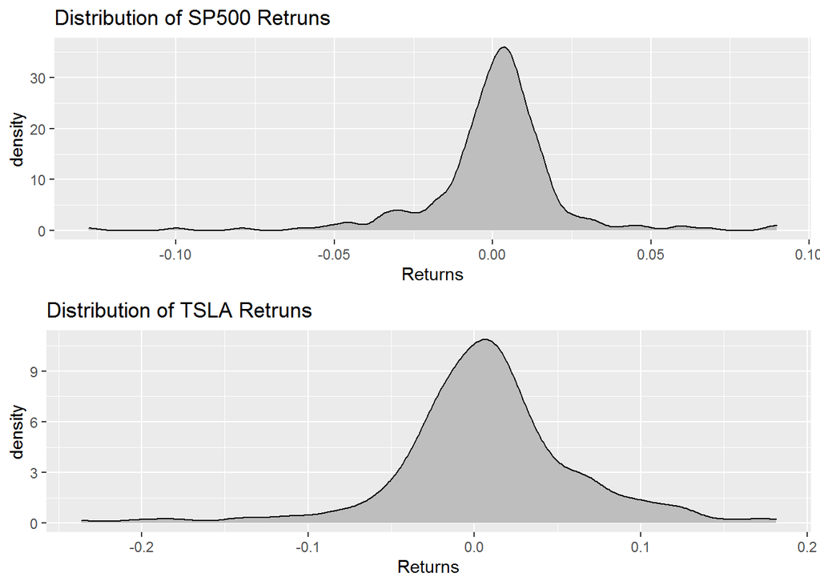

```r
plot5 <- ggplot(na.omit(data))+
          geom_density(aes(SP500_r), fill = "Grey")+
          labs(title = "Distribution of SP500 Retruns",
               x = "Returns")

plot6 <- ggplot(na.omit(data))+
          geom_density(aes(TSLA_r), fill = "Grey")+
          labs(title = "Distribution of TSLA Retruns",
               x = "Returns")

grid.arrange(plot5,
             plot6,
             nrow = 2)
```

Tests below confirm our conclusions.

```r
#Testing normality of distribution of SP500 returns with Shapiro-Wilk test.
#H0: data normaly distributed;
#H1: data is not normaly distributied;
shapiro.test(sp500_ts)
```

```
##
##  Shapiro-Wilk normality test
##
## data:  sp500_ts
## W = 0.84055, p-value = 1.97e-15
```

```r
#Testing normality of distribution of TSLA returns with Shapiro-Wilk test.
#H0: data normaly distributed;
#H1: data is not normaly distributied;
shapiro.test(tsla_ts)
```

```
##
##  Shapiro-Wilk normality test
##
## data:  tsla_ts
## W = 0.93567, p-value = 4.627e-09
```

Correlation is not strong, only 50%. At this point, before proceeding to the study of ACFs, PACFs and CCFs, we can estimate a static beta for Tesla stock.

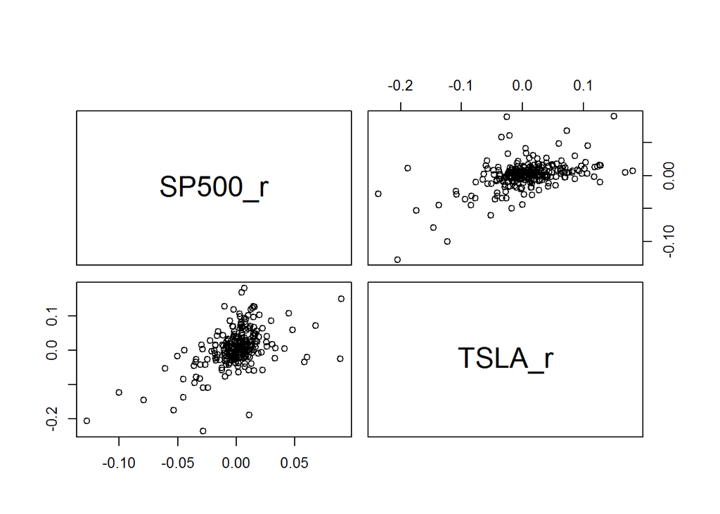

```r
#Static CCM plot.
pairs(~ SP500_r + TSLA_r, data = na.omit(data), main = NA)
```

```r
#Static CCM numerical.
cor(na.omit(data[,4:5]))
```

```
##           SP500_r    TSLA_r
## SP500_r 1.0000000 0.5055387
## TSLA_r  0.5055387 1.0000000
```

```r
#Calculating standard deviations of returns.
SD <- c(sd(sp500_ts), sd(tsla_ts))
names(SD) <- c("SP500", "TSLA")
SD
```

```
##      SP500       TSLA
## 0.02179032 0.05509240
```

```r
#Calculating beta for TSLA.
tsla_beta <- lm(tsla_ts ~ sp500_ts)
tsla_beta
```

```
##
## Call:
## lm(formula = tsla_ts ~ sp500_ts)
##
## Coefficients:
## (Intercept)     sp500_ts
##    0.006272     1.278152
```

ACF and PACF of S&P500 show the presence of autocorrelations, while Telsa returns seem to be not autocorrelated.

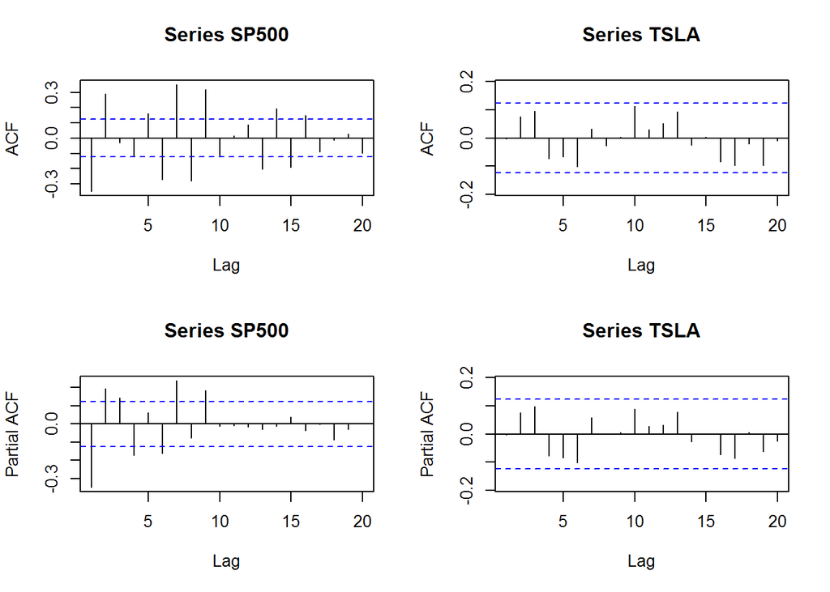

```r
#Plotting ACFs and PACFS.
par(mfrow = c(2,2) )
Acf(sp500_ts, lag.max = 20, main = "Series SP500")
Acf(tsla_ts, lag.max = 20, main = "Series TSLA")
Pacf(sp500_ts, lag.max = 20, main = "Series SP500")
Pacf(tsla_ts, lag.max = 20, main = "Series TSLA")
```

The hypothesis is confirmed by the Ljung-Box tests.

```r
#Ljung-Box for detecting autocorrelations in SP500 returns.
#H0: all correlations are zero;
#H1: there exists at least one, which is significantly higher than zero;
Box.test(sp500_ts, lag = 30, type = "Ljung-Box")
```

```
##
##  Box-Ljung test
##
## data:  sp500_ts
## X-squared = 223.81, df = 30, p-value < 2.2e-16
```

```r
#Ljung-Box for detecting autocorrelations in TSLA returns.
#H0: all correlations are zero;
#H1: there exists at least one, which is significantly higher than zero;
Box.test(tsla_ts, lag = 30, type = "Ljung-Box")
```

```
##
##  Box-Ljung test
##
## data:  tsla_ts
## X-squared = 30.647, df = 30, p-value = 0.4329
```

It is worth to underline, that SP&500 is a predictor, and Tesla is a response variable. There is some correlation at the lag 2, and weaker correlation at lag -2, which means Tesla returns respond more to S&P500 impulses at that lag, rather than vice versa.

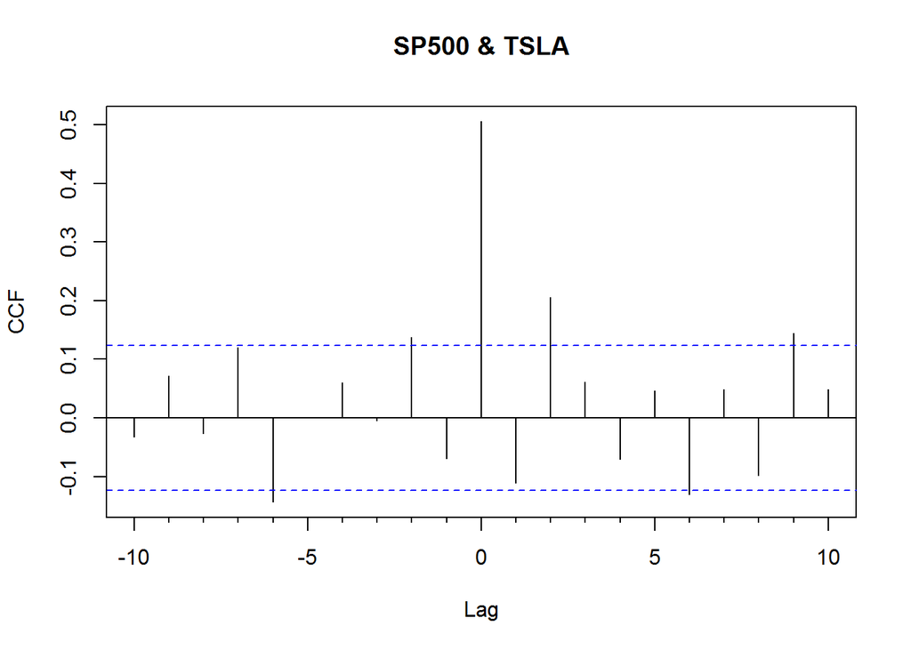

```r
#Plotting lagged ctoss-correlation function.
Ccf(data$SP500_r, data$TSLA_r, lag.max = 10, main = "SP500 & TSLA")
```

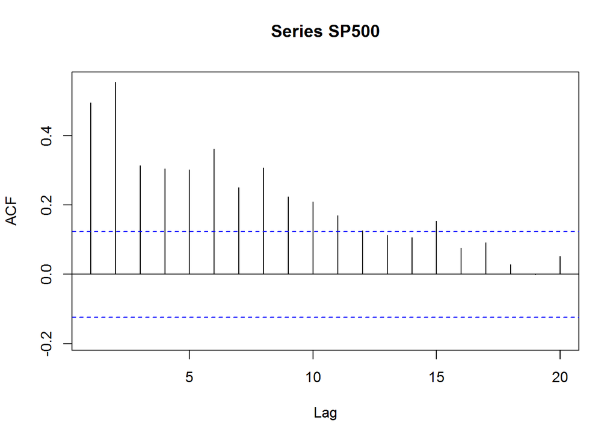

```r
#ACF of squared SP500 series.
Acf(na.omit(sp500_ts)^2, lag.max = 20, main = "Series SP500")
```

The ACF plots of squared series of S&P500 and Tesla returns suggest, that the data is dependent and somewhat correlated in case of S&P500, and just dependent in case of Tesla, despite being weakly autocorrelated. Further ARCH testing shows the presence of ARCH effect in both cases.

```r
#Testing ARCH effect in SP500 returns.
#H0: there is no ARCH effect;
#H1: there is ARCH effect with a specified lag;
archtest(as.vector(sp500_ts), lag = 2)
```

```
##
##  Engle's LM ARCH Test
##
## data:  as.vector(sp500_ts)
## statistic = 93.157, lag = 2, p-value < 2.2e-16
## alternative hypothesis: ARCH effects of order 2 are present
```

```r
archtest(as.vector(sp500_ts), lag = 5)
```

```
##
##  Engle's LM ARCH Test
##
## data:  as.vector(sp500_ts)
## statistic = 97.745, lag = 5, p-value < 2.2e-16
## alternative hypothesis: ARCH effects of order 5 are present
```

```r
archtest(as.vector(sp500_ts), lag = 10)
```

```
##
##  Engle's LM ARCH Test
##
## data:  as.vector(sp500_ts)
## statistic = 104.71, lag = 10, p-value < 2.2e-16
## alternative hypothesis: ARCH effects of order 10 are present
```

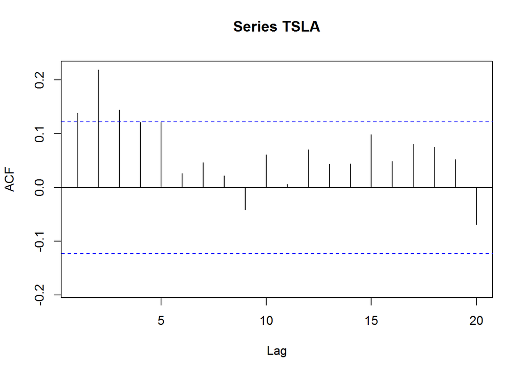

```r
#ACF of squared TSLA series.
Acf(na.omit(tsla_ts)^2, lag.max = 20, main = "Series TSLA")
```

```r
#Testing ARCH effect in TSLA returns.
#H0: there is no ARCH effect;
#H1: there is ARCH effect with a specified lag;
archtest(as.vector(tsla_ts), lag = 2)
```

```
##
##  Engle's LM ARCH Test
##
## data:  as.vector(tsla_ts)
## statistic = 17.391, lag = 2, p-value = 0.0001673
## alternative hypothesis: ARCH effects of order 2 are present
```

```r
archtest(as.vector(tsla_ts), lag = 5)
```

```
##
##  Engle's LM ARCH Test
##
## data:  as.vector(tsla_ts)
## statistic = 20.048, lag = 5, p-value = 0.001224
## alternative hypothesis: ARCH effects of order 5 are present
```

```r
archtest(as.vector(tsla_ts), lag = 10)
```

```
##
##  Engle's LM ARCH Test
##
## data:  as.vector(tsla_ts)
## statistic = 22.064, lag = 10, p-value = 0.01478
## alternative hypothesis: ARCH effects of order 10 are present
```

Multivariate Ljung-Box statistics rejects zero hypotheses, so we can use the VAR mean model for the DCC model.

```r
#Multivariate Ljung-Box statistics.
pdf(file = NULL)
mq(na.omit(data[,4:5]), lag = 15)
```

```
## Ljung-Box Statistics:
##         m       Q(m)     df    p-value
##  [1,]   1.0      36.0     4.0        0
##  [2,]   2.0      59.2     8.0        0
##  [3,]   3.0      63.0    12.0        0
##  [4,]   4.0      75.4    16.0        0
##  [5,]   5.0      85.7    20.0        0
##  [6,]   6.0     105.5    24.0        0
##  [7,]   7.0     145.0    28.0        0
##  [8,]   8.0     171.4    32.0        0
##  [9,]   9.0     201.0    36.0        0
## [10,]  10.0     211.4    40.0        0
## [11,]  11.0     212.9    44.0        0
## [12,]  12.0     216.6    48.0        0
## [13,]  13.0     242.2    52.0        0
## [14,]  14.0     259.2    56.0        0
## [15,]  15.0     272.2    60.0        0
```

```r
invisible(dev.off())
```

The last impotant test is a stationarity test. In both cases the data follow a stationary process.

```r
#Testing stationarity of SP500 returns.
#H0: non-stationary;
#H1: stationary;
adf.test(sp500_ts)
```

```
##
##  Augmented Dickey-Fuller Test
##
## data:  sp500_ts
## Dickey-Fuller = -5.1471, Lag order = 6, p-value = 0.01
## alternative hypothesis: stationary
```

```r
#Testing stationarity of TSLA returns.
#H0: non-stationary;
#H1: stationary;
adf.test(tsla_ts)
```

```
##
##  Augmented Dickey-Fuller Test
##
## data:  tsla_ts
## Dickey-Fuller = -6.2497, Lag order = 6, p-value = 0.01
## alternative hypothesis: stationary
```

# 3 ARMA Model For S&P500

For our DCC model we need to specify GARCH models for the series of returns. In another turn, for the GARCH model we should build mean models. After some trials and erros, the best specification is presented below. It is very helpful to look at PACF function of residuals in order to find the best specification for MA process. It allows to eliminate correlations in residuals.

```r
#Building the ARMA model for SP500.
sp500_arma <- arma(sp500_xts, order = c(0,2), list(ar = c(6,8), ma = c(1,2,9,7)))
summary(sp500_arma)
```

```
##
## Call:
## arma(x = sp500_xts, order = c(0, 2), lag = list(ar = c(6, 8),     ma = c(1, 2, 9, 7)))
##
## Model:
## ARMA(8,9)
##
## Residuals:
##       Min        1Q    Median        3Q       Max
## -0.098121 -0.006674  0.001642  0.008730  0.088072
##
## Coefficient(s):
##             Estimate  Std. Error  t value Pr(>|t|)
## ar6       -0.1499937   0.0618764   -2.424 0.015347 *
## ar8       -0.1430343   0.0639182   -2.238 0.025236 *
## ma1       -0.2098927   0.0607710   -3.454 0.000553 ***
## ma2        0.2443467   0.0666438    3.666 0.000246 ***
## ma9        0.2540560   0.0620261    4.096  4.2e-05 ***
## ma7        0.1600439   0.0594443    2.692 0.007095 **
## intercept  0.0007166   0.0017016    0.421 0.673665
## ---
## Signif. codes:  0 '***' 0.001 '**' 0.01 '*' 0.05 '.' 0.1 ' ' 1
##
## Fit:
## sigma^2 estimated as 0.0003603,  Conditional Sum-of-Squares = 0.09,  AIC = -1273.93
```

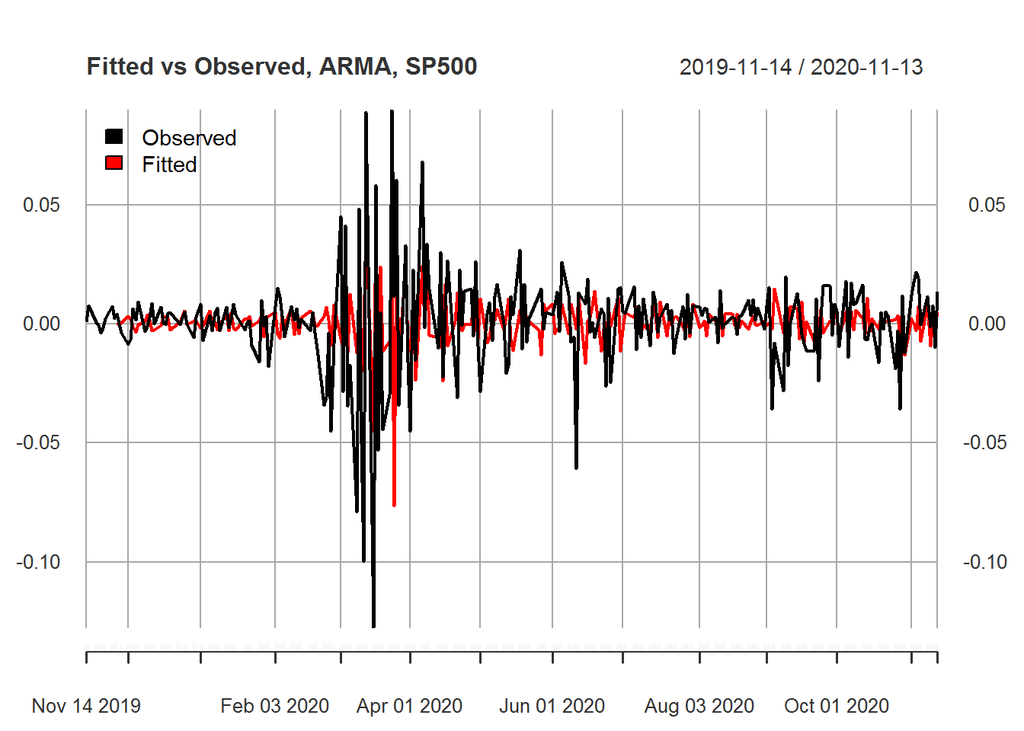

```r
#Plotting fitted values against observed ones.
plot(cbind("Observed" = sp500_xts,
            "Fitted" = xts(sp500_arma$fitted.values, order.by = na.omit(data)$Date)),
     col = c("black", "red"),
     legend.loc = "topleft",
     main = "Fitted vs Observed, ARMA, SP500",
     lwd = c(2,2))
```

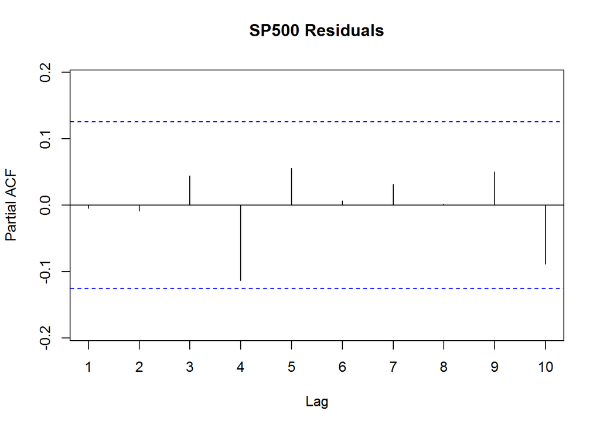

```r
#Plotting PACF function of SP500 ARMA residuals.
Pacf(sp500_arma$residuals, lag.max = 10, main = "SP500 Residuals")
```

In our case, the only problem is the distribution of residuals, which is not normal. It is well seen and also Shapiro-Wilk normality test rejects H0. Left tail is very fat, combining it with the plot of fitted values, we can conclude the model is bad in estimation of excess negative returns.

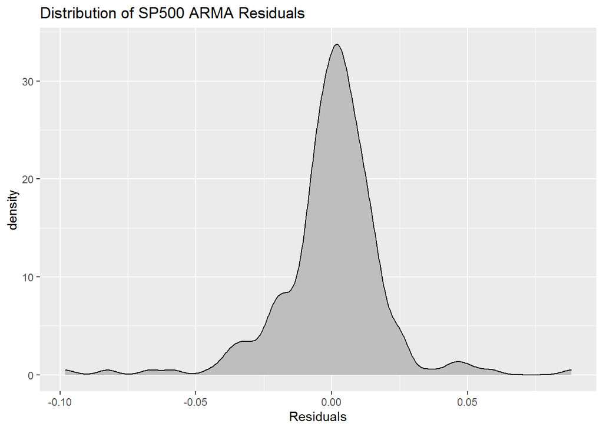

```r
#Plotting the distribution of residuals.
ggplot(na.omit(data.frame("Residuals" = sp500_arma$residuals)))+
          geom_density(aes(Residuals), fill = "Grey")+
          labs(title = "Distribution of SP500 ARMA Residuals",
               x = "Residuals")
```

```r
#Testing normality of distribution of SP500 ARMAA residuals with Shapiro-Wilk test.
#H0: data normaly distributed;
#H1: data is not normaly distributied;
shapiro.test(sp500_arma$residuals)
```

```
##
##  Shapiro-Wilk normality test
##
## data:  sp500_arma$residuals
## W = 0.89317, p-value = 4.009e-12
```

The PACF plot of squared residuals suggests to use alpha parameters with a lag no greater than two.

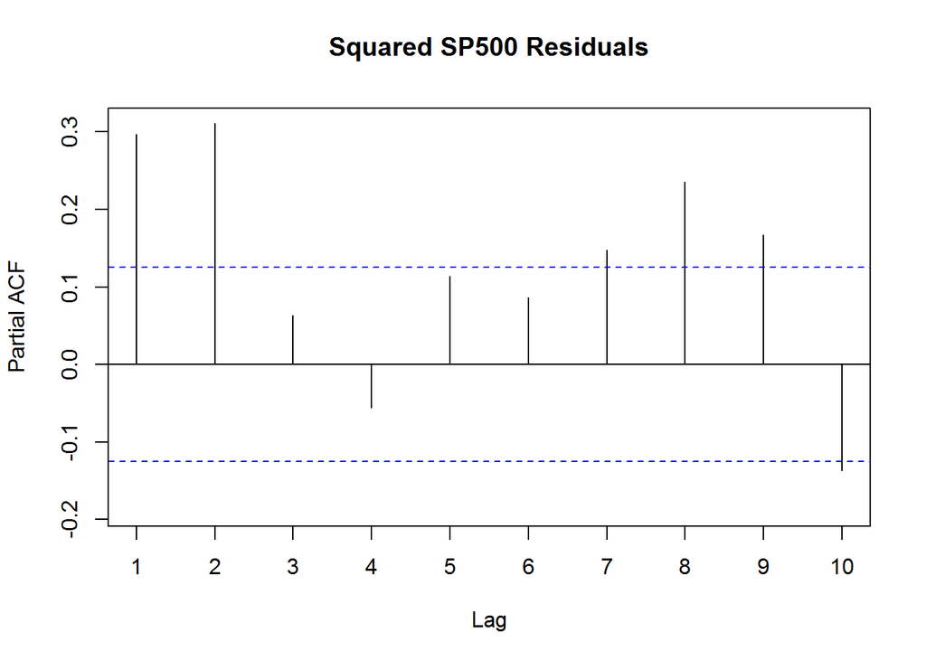

```r
#Plotting PACF of squared SP500 ARMA residuals.
Pacf(sp500_arma$residuals^2, lag.max = 10, main = "Squared SP500 Residuals")
```

# 4 GARCH Model for S&P500

```r
#Building GARCH model for SP500.
sp500_garch_spec <- ugarchspec(mean.model = list(armaOrder = c(8,9), include.mean = FALSE),
                                fixed.pars = list("ar1" = 0,
                                                  "ar2" = 0,
                                                  "ar3" = 0,
                                                  "ar4" = 0,
                                                  "ar5" = 0,
                                                  "ar6" = -0.1499937,
                                                  "ar7" = 0,
                                                  "ar8" = 0.0639182,
                                                  "ma1" = 0.0607710,
                                                  "ma2" = 0.2443467,
                                                  "ma3" = 0,
                                                  "ma4" = 0,
                                                  "ma5" = 0,
                                                  "ma6" = 0,
                                                  "ma7" = 0.1600439,
                                                  "ma8" = 0,
                                                  "ma9" = 0.2540560),
                          variance.model = list(model = "sGARCH", garchOrder = c(1,1)),
                          distribution.model = "sstd")

sp500_garch <- ugarchfit(sp500_garch_spec, data = sp500_xts)
show(sp500_garch)
```

```
##
## *---------------------------------*
## *          GARCH Model Fit        *
## *---------------------------------*
##
## Conditional Variance Dynamics
## -----------------------------------
## GARCH Model  : sGARCH(1,1)
## Mean Model   : ARFIMA(8,0,9)
## Distribution : sstd
##
## Optimal Parameters
## ------------------------------------
##         Estimate  Std. Error  t value Pr(>|t|)
## ar1     0.000000          NA       NA       NA
## ar2     0.000000          NA       NA       NA
## ar3     0.000000          NA       NA       NA
## ar4     0.000000          NA       NA       NA
## ar5     0.000000          NA       NA       NA
## ar6    -0.149994          NA       NA       NA
## ar7     0.000000          NA       NA       NA
## ar8     0.063918          NA       NA       NA
## ma1     0.060771          NA       NA       NA
## ma2     0.244347          NA       NA       NA
## ma3     0.000000          NA       NA       NA
## ma4     0.000000          NA       NA       NA
## ma5     0.000000          NA       NA       NA
## ma6     0.000000          NA       NA       NA
## ma7     0.160044          NA       NA       NA
## ma8     0.000000          NA       NA       NA
## ma9     0.254056          NA       NA       NA
## omega   0.000008    0.000006   1.3557 0.175195
## alpha1  0.230577    0.060233   3.8281 0.000129
## beta1   0.768423    0.051846  14.8213 0.000000
## skew    0.710269    0.066217  10.7264 0.000000
## shape   7.529624    3.889502   1.9359 0.052882
##
## Robust Standard Errors:
##         Estimate  Std. Error  t value Pr(>|t|)
## ar1     0.000000          NA       NA       NA
```

[output cut: 74 more lines]

```
## Negative Sign Bias  0.3157 0.75246
## Positive Sign Bias  0.1593 0.87357
## Joint Effect        4.4958 0.21266
##
##
## Adjusted Pearson Goodness-of-Fit Test:
## ------------------------------------
##   group statistic p-value(g-1)
## 1    20     15.54       0.6879
## 2    30     29.81       0.4237
## 3    40     36.17       0.5997
## 4    50     46.41       0.5789
##
##
## Elapsed time : 0.2120118
```

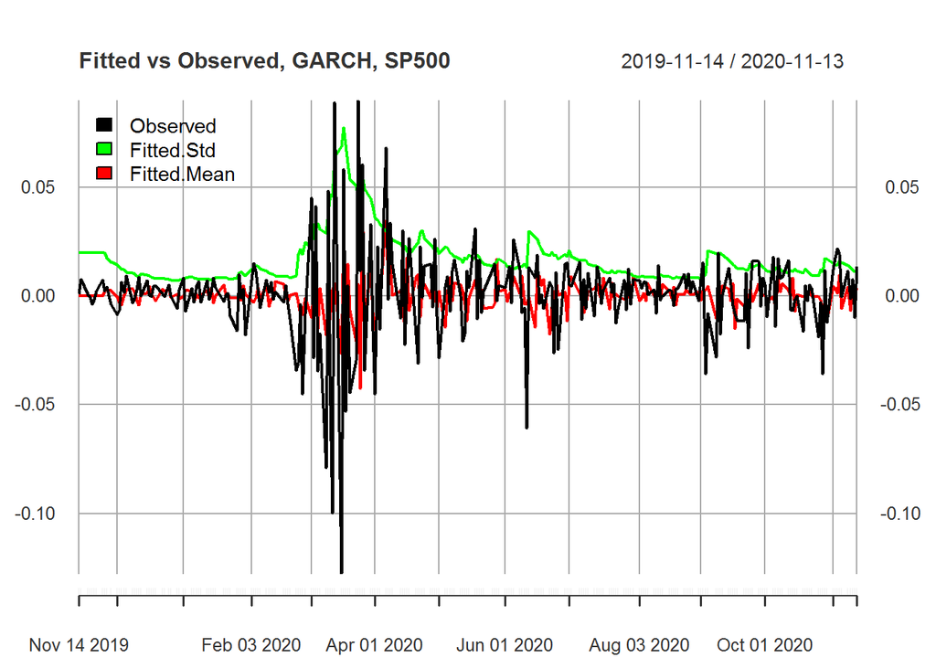

```r
#Plotting fitted mean and std for SP500.
plot(cbind('Observed' = sp500_xts,
           'Fitted Std' = sigma(sp500_garch),
           'Fitted Mean' = fitted(sp500_garch)),
     col = c("black", "green", "red"),
     legend.loc = "topleft",
     main = "Fitted vs Observed, GARCH, SP500",
     lwd = c(2,2,2))
```

# 5 ARMA model for Tesla

We pick (2,2) specification for the Tesla ARMA model. The plot with fitted values is presented below. The model has the same problem as the previous one – the residuals are not distributed normally. It is visible in the distribution plot.

```r
#Building the ARMA model for TSLA
tsla_arma <- arma(tsla_ts, order = c(2,2))
summary(tsla_arma)
```

```
##
## Call:
## arma(x = tsla_ts, order = c(2, 2))
##
## Model:
## ARMA(2,2)
##
## Residuals:
##       Min        1Q    Median        3Q       Max
## -0.222526 -0.027487 -0.004011  0.023948  0.172681
##
## Coefficient(s):
##            Estimate  Std. Error  t value Pr(>|t|)
## ar1        0.646804    0.185977    3.478 0.000505 ***
## ar2       -0.595051    0.289798   -2.053 0.040041 *
## ma1       -0.667043    0.158238   -4.215 2.49e-05 ***
## ma2        0.724199    0.255869    2.830 0.004650 **
## intercept  0.006762    0.004191    1.613 0.106638
## ---
## Signif. codes:  0 '***' 0.001 '**' 0.01 '*' 0.05 '.' 0.1 ' ' 1
##
## Fit:
## sigma^2 estimated as 0.002977,  Conditional Sum-of-Squares = 0.74,  AIC = -743.64
```

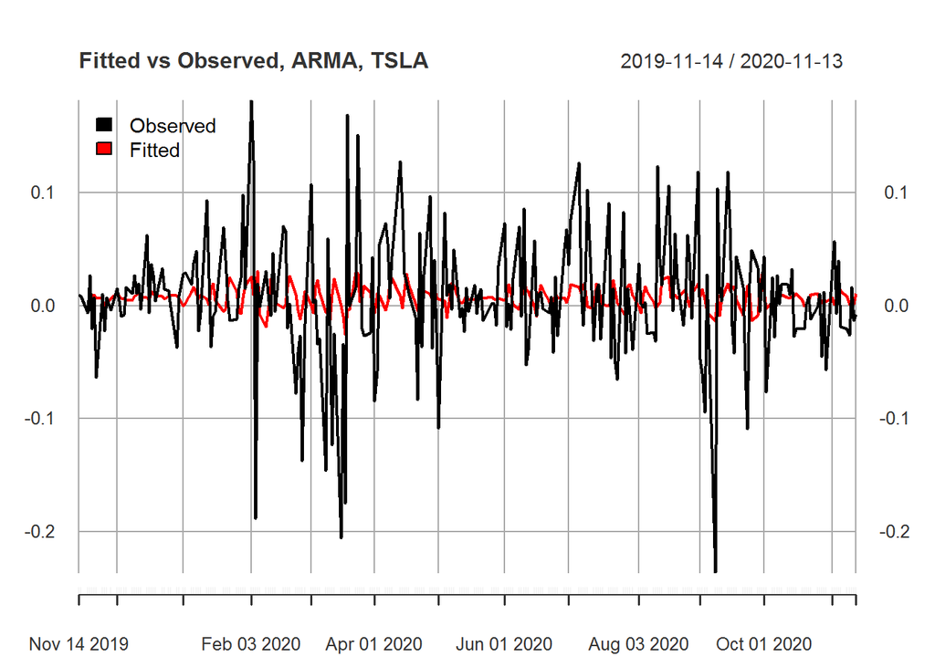

```r
#Plotting fitted values against observed ones.
plot(cbind("Observed" = tsla_xts,
            "Fitted" = xts(tsla_arma$fitted.values, order.by = na.omit(data)$Date)),
     col = c("black", "red"),
     legend.loc = "topleft",
     main = "Fitted vs Observed, ARMA, TSLA",
     lwd = c(2,2))
```

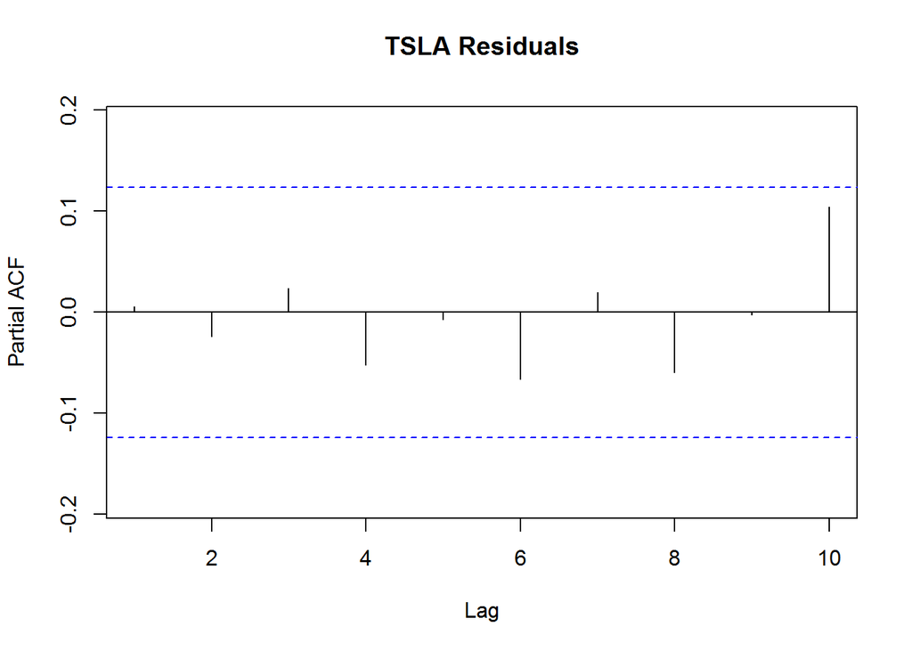

```r
#Plotting PACF function of TSLA ARMA residuals.
Pacf(tsla_arma$residuals, lag.max = 10, main = "TSLA Residuals")
```

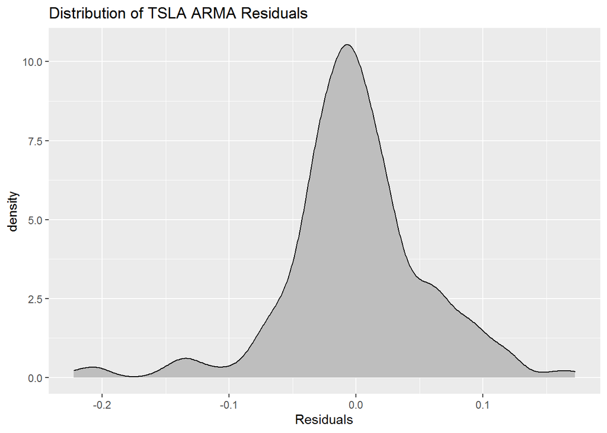

```r
#Plotting the distribution of residuals.
ggplot(na.omit(data.frame("Residuals" = tsla_arma$residuals)))+
          geom_density(aes(Residuals), fill = "Grey")+
          labs(title = "Distribution of TSLA ARMA Residuals",
               x = "Residuals")
```

```r
#Testing normality of distribution of TSLA ARMAA residuals with Shapiro-Wilk test.
#H0: data normaly distributed;
#H1: data is not normaly distributied;
shapiro.test(tsla_arma$residuals)
```

```
##
##  Shapiro-Wilk normality test
##
## data:  tsla_arma$residuals
## W = 0.94917, p-value = 1.128e-07
```

Here is the same situation as with S&P500.

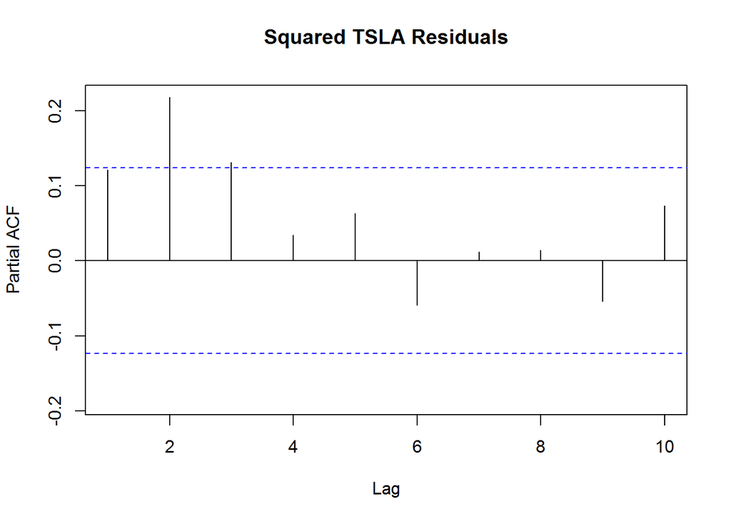

```r
#Plotting PACF function of Squared TSLA ARMA residuals.
Pacf(tsla_arma$residuals^2, lag.max = 10, main = "Squared TSLA Residuals")
```

# 6 GARCH model for Tesla

The picture is similar to S&P500 GARCH model. The plot of results is below,

```r
#Building GARCH model for TSLA.
tsla_garch_spec <- ugarchspec(mean.model = list(armaOrder = c(2,2), include.mean = TRUE),
                          variance.model = list(model = "sGARCH", garchOrder = c(1,1)),
                          distribution.model = "sstd")

tsla_garch <- ugarchfit(tsla_garch_spec, data = tsla_xts)
show(tsla_garch)
```

```
##
## *---------------------------------*
## *          GARCH Model Fit        *
## *---------------------------------*
##
## Conditional Variance Dynamics
## -----------------------------------
## GARCH Model  : sGARCH(1,1)
## Mean Model   : ARFIMA(2,0,2)
## Distribution : sstd
##
## Optimal Parameters
## ------------------------------------
##         Estimate  Std. Error   t value Pr(>|t|)
## mu      0.007092    0.002854    2.4850 0.012954
## ar1     1.536169    0.011218  136.9400 0.000000
## ar2    -0.987147    0.008862 -111.3868 0.000000
## ma1    -1.524849    0.002218 -687.3796 0.000000
## ma2     0.992449    0.002192  452.6746 0.000000
## omega   0.000186    0.000125    1.4836 0.137926
## alpha1  0.270843    0.114013    2.3755 0.017524
## beta1   0.728157    0.089246    8.1590 0.000000
## skew    1.074552    0.092286   11.6437 0.000000
## shape   3.824612    1.149150    3.3282 0.000874
##
## Robust Standard Errors:
##         Estimate  Std. Error   t value Pr(>|t|)
## mu      0.007092    0.003300    2.1493 0.031612
## ar1     1.536169    0.007681  200.0007 0.000000
## ar2    -0.987147    0.009137 -108.0406 0.000000
## ma1    -1.524849    0.002868 -531.6275 0.000000
## ma2     0.992449    0.001358  730.9277 0.000000
## omega   0.000186    0.000108    1.7170 0.085987
## alpha1  0.270843    0.109410    2.4755 0.013305
## beta1   0.728157    0.081067    8.9821 0.000000
## skew    1.074552    0.095204   11.2868 0.000000
## shape   3.824612    1.077509    3.5495 0.000386
##
## LogLikelihood : 415.454
##
```

[output cut: 55 more lines]

```
## Negative Sign Bias  0.8820 0.3786
## Positive Sign Bias  0.8427 0.4002
## Joint Effect        1.5281 0.6758
##
##
## Adjusted Pearson Goodness-of-Fit Test:
## ------------------------------------
##   group statistic p-value(g-1)
## 1    20     10.64       0.9355
## 2    30     18.90       0.9239
## 3    40     21.31       0.9905
## 4    50     36.53       0.9062
##
##
## Elapsed time : 0.461026
```

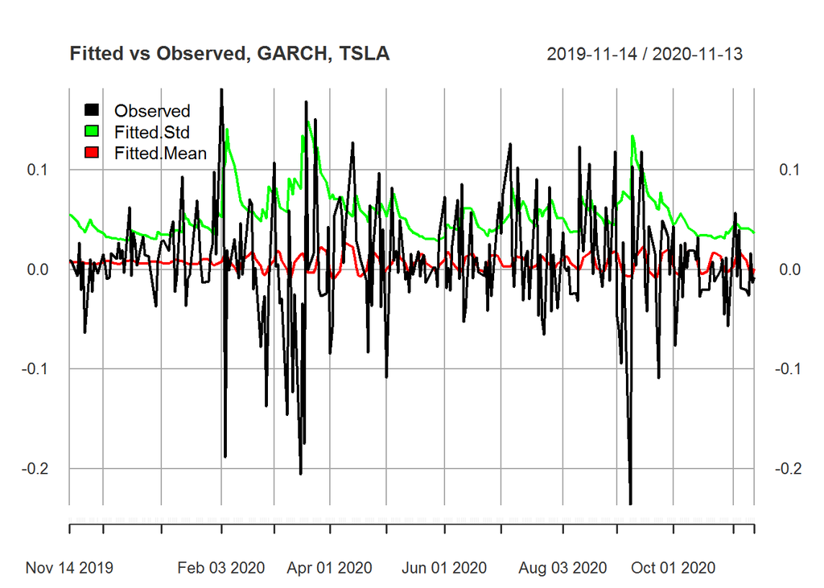

```r
#Plotting fitted mean and std for SP500.
plot(cbind('Observed' = tsla_xts,
           'Fitted Std' = sigma(tsla_garch),
           'Fitted Mean' = fitted(tsla_garch)),
     col = c("black", "green", "red"),
     legend.loc = "topleft",
     main = "Fitted vs Observed, GARCH, TSLA",
     lwd = c(2,2,2))
```

# 7 DCC Model For S&P500 And Tesla

In order to facilitate the process of building the DCC model, we can use “HQ” criterion and specify the max lag order, so the function ‘dccfit’ would pick the VAR model with the lowest criterion. The built model uses multivariate student-t distribution.

```r
#Building DCC model.
dcc.garch.spec <- dccspec(uspec = multispec(c(sp500_garch_spec, tsla_garch_spec)),
                           VAR = TRUE,
                           lag.max = 5,
                           lag.criterion = "HQ",
                           dccOrder = c(1,1),
                           distribution = "mvt")


dcc.fit <- dccfit(dcc.garch.spec, data = whole)
dcc.fit
```

```
##
## *---------------------------------*
## *          DCC GARCH Fit          *
## *---------------------------------*
##
## Distribution         :  mvt
## Model                :  DCC(1,1)
## No. Parameters       :  20
## [VAR GARCH DCC UncQ] : [6+10+3+1]
## No. Series           :  2
## No. Obs.             :  253
## Log-Likelihood       :  1166.759
## Av.Log-Likelihood    :  4.61
##
## Optimal Parameters
## -----------------------------------
##                 Estimate  Std. Error  t value Pr(>|t|)
## [SP500].omega   0.000007    0.000009  0.80939 0.418290
## [SP500].alpha1  0.216708    0.052684  4.11338 0.000039
## [SP500].beta1   0.782291    0.059253 13.20248 0.000000
## [SP500].skew    0.742796    0.083848  8.85889 0.000000
## [SP500].shape   5.262467    2.193857  2.39873 0.016452
## [TSLA].omega    0.000168    0.000124  1.35685 0.174828
## [TSLA].alpha1   0.223444    0.095907  2.32979 0.019817
## [TSLA].beta1    0.775556    0.093221  8.31953 0.000000
## [TSLA].skew     1.046707    0.058989 17.74411 0.000000
## [TSLA].shape    3.543969    0.703660  5.03648 0.000000
## [Joint]dcca1    0.075835    0.042316  1.79212 0.073113
## [Joint]dccb1    0.754821    0.093366  8.08456 0.000000
## [Joint]mshape   5.002016    0.844686  5.92175 0.000000
##
## Information Criteria
## ---------------------
##
## Akaike       -9.0653
## Bayes        -8.7860
## Shibata      -9.0766
## Hannan-Quinn -8.9529
##
##
## Elapsed time : 1.477085
```

Now we can extract conditional standard deviations and correlations, as well as calculate rolling equivalents for comparison. The results are shown in the plot below.

```r
#Calculating conditional standard deviations.
cond.std <- sigma(dcc.fit)^0.5
```

```r
#Calculating conditional correlations.
cond.cor <- rcor(dcc.fit)
cond.cor <- as.xts(cond.cor[1,2,], order.by = index(whole))
```

```r
#Calculating rolling standard deviations.
roll.sd.sp500 <- roll_sd(sp500_xts, width = 20)
roll.sd.tsla <- roll_sd(tsla_xts, width = 20)
```

```r
#Calculating rolling correlations.
roll.cor <- as.vector(roll_cor(sp500_xts, tsla_xts, width = 20))
```

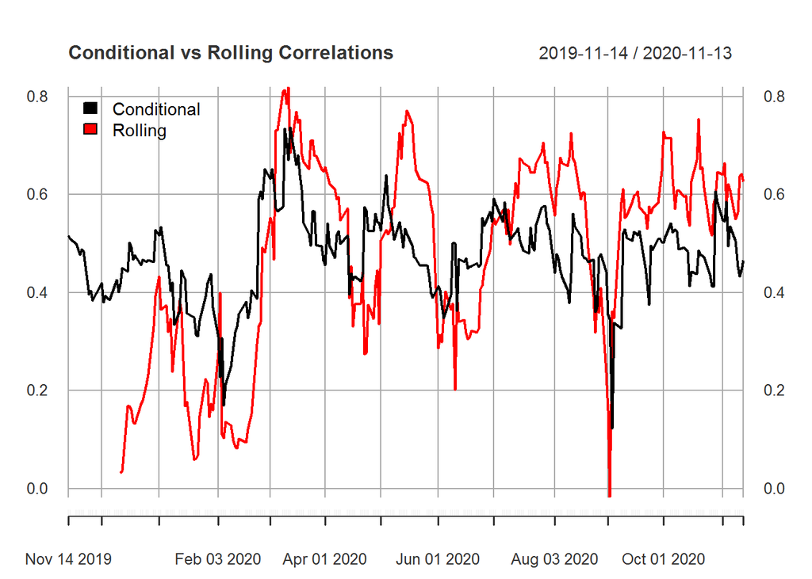

```r
#Plotting conditional correlations vs rolling correlations.
plot(cbind("Conditional" = cond.cor,
           "Rolling" = roll.cor),
     col = c("black", "red"),
     legend.loc = "topleft",
     main = "Conditional vs Rolling Correlations",
     lwd = c(2,2))
```

# 8 Dynamic Conditional Betas And Its Alternatives

The final stage is a calculation of conditional dynamic and rolling betas. The final results are shown in the plot below. As we see, dynamic conditional betas seldom exceed the value of the static beta, while rolling betas are not stable. If we assume that conditional dynamic betas are more robust than rolling betas, then we can conclude that Tesla stock is either less volatile than the index or it is weakly correlated with it. We know for sure the last one is true, while the first one seems to be false, thus the reliability of the results can be justified to some degree.

```r
#Calculating conditional betas.
cond.beta <- cond.std[,2]/cond.std[,1] * cond.cor
names(cond.beta) <- c("Conditional")
```

```r
#Calculating rolling betas.
roll.beta <- roll.cor * roll.sd.tsla /roll.sd.sp500
```

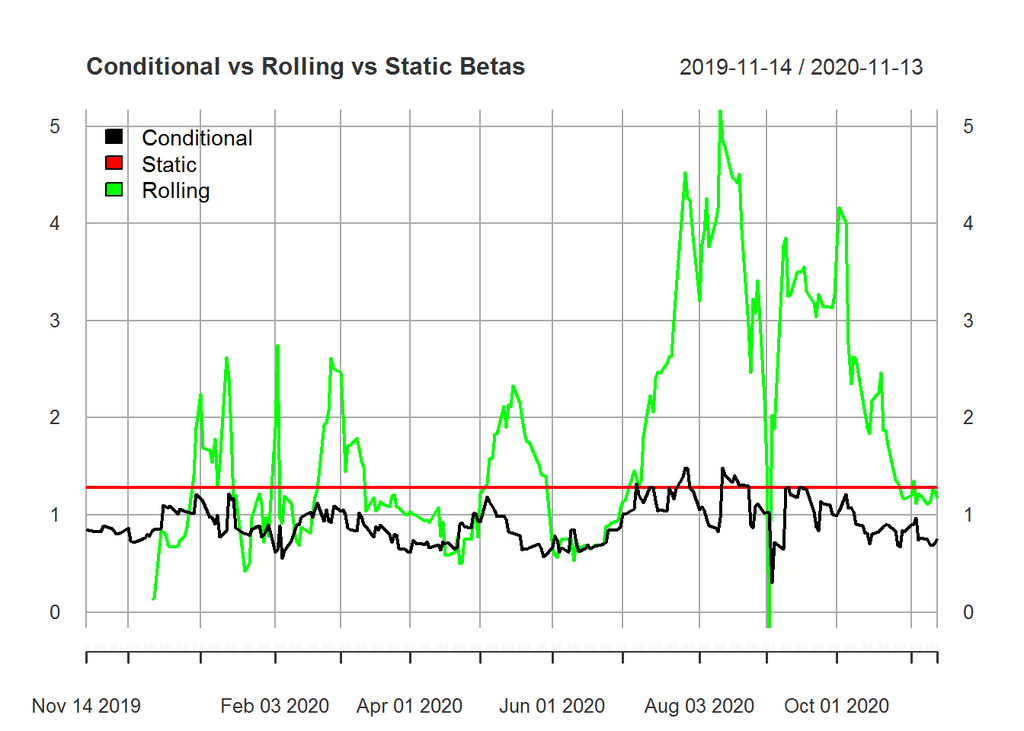

```r
#Plotting betas.
plot(cbind("Conditional" = cond.beta,
           "Static" =  rep(tsla_beta$coefficients[2], length(cond.beta)),
           "Rolling" = roll.beta),
     col = c("black", "red", "green"),
     legend.loc = "topleft",
     main = "Conditional vs Rolling vs Static Betas",
     lwd = c(2,2))
```

Here is a supplementary summary of every variable.

```r
#Summary of conditional betas.
summary(cond.beta)
```

```
##      Index             Conditional
##  Min.   :2019-11-14   Min.   :0.2984
##  1st Qu.:2020-02-18   1st Qu.:0.7660
##  Median :2020-05-18   Median :0.8811
##  Mean   :2020-05-17   Mean   :0.9175
##  3rd Qu.:2020-08-17   3rd Qu.:1.0447
##  Max.   :2020-11-13   Max.   :1.4851
```

```r
#Summary of rolled betas.
summary(roll.beta)
```

```
##      Index              roll.beta
##  Min.   :2019-11-14   Min.   :-0.1611
##  1st Qu.:2020-02-18   1st Qu.: 0.9539
##  Median :2020-05-18   Median : 1.4106
##  Mean   :2020-05-17   Mean   : 1.8175
##  3rd Qu.:2020-08-17   3rd Qu.: 2.4646
##  Max.   :2020-11-13   Max.   : 5.1653
##                       NA's   :19
```

```r
#Static beta.
tsla_beta
```

```
##
## Call:
## lm(formula = tsla_ts ~ sp500_ts)
##
## Coefficients:
## (Intercept)     sp500_ts
##    0.006272     1.278152
```